# Introdução à economia

Aula 23 - Rendimentos e discriminação

Prof. Roberto de Freitas Neder

## Aula 23: roteiro

**Rendimentos e discriminação** · Mankiw, capítulo 19 · UnB

- Determinantes dos salários
- Informação e mercados
- Instituições salariais
- Discriminação e evidência
- Conclusão
- Exercícios de concursos públicos

Use as setas para trocar de slide. Nas páginas longas, role o conteúdo. As respostas das atividades ficam fechadas até o clique.

## 01 - Por que os rendimentos diferem?

Trabalhadores recebem remunerações diferentes mesmo dentro de uma mesma ocupação. Os empregos também diferem em risco, conforto, estabilidade e possibilidades de aprendizagem.

O capítulo examina características dos postos e das pessoas, educação, sinalização, grandes mercados e instituições salariais. Depois, discute **discriminação no mercado de trabalho**.

Explicar uma diferença de renda não equivale a considerá-la justa. E observar uma diferença não basta para identificar uma única causa.

**Base:** Mankiw, capítulo 19, *Earnings and Discrimination*, pp. 383 a 399. PDF: pp. 412 a 428.

← Menu

## 02 - Retomando a demanda por trabalho

Na referência competitiva, a firma compara o valor do produto marginal do trabalho com o salário. Mas trabalhadores e empregos não são todos iguais.

Diferenças de qualificação, tecnologia utilizada, preço do produto e condições do posto modificam demanda e oferta.

Uma enfermeira, um técnico de manutenção e um artista atuam em mercados distintos. Mesmo dentro de cada grupo, jornada e benefícios precisam ser comparáveis.

Antes de comparar salários, pergunte se os valores são mensais ou por hora, brutos ou líquidos e se incluem componentes variáveis e benefícios.

← Menu

## 03 - Diferenciais compensatórios

Um **diferencial compensatório** é uma diferença salarial associada a características não monetárias do emprego.

Trabalho noturno, risco, localização isolada e desconforto podem exigir remuneração maior para atrair pessoas com alternativas comparáveis. Um posto agradável ou com flexibilidade pode atrair candidatos a salário menor.

O mecanismo pressupõe que trabalhadores conheçam as condições e tenham possibilidades de escolha.

Uma remuneração maior por risco não elimina a necessidade de proteção, nem demonstra que qualquer exposição seja aceitável. Sem alternativas, trabalhadores podem enfrentar condições ruins sem compensação adequada.

← Menu

## 04 - Comparação entre dois postos

**Exemplo didático:** dois postos exigem a mesma qualificação e produzem o mesmo resultado, mas um funciona à noite e o outro durante o dia.

Se menos pessoas desejam trabalhar à noite a cada salário, a oferta para esse turno pode ser menor e a remuneração de equilíbrio maior.

Para identificar o diferencial, precisaríamos controlar jornada, experiência, produtividade, localização e benefícios.

Comparar apenas as médias dos dois turnos mistura o efeito das condições de trabalho com a composição dos trabalhadores contratados.

← Menu

## 05 - O diferencial no gráfico

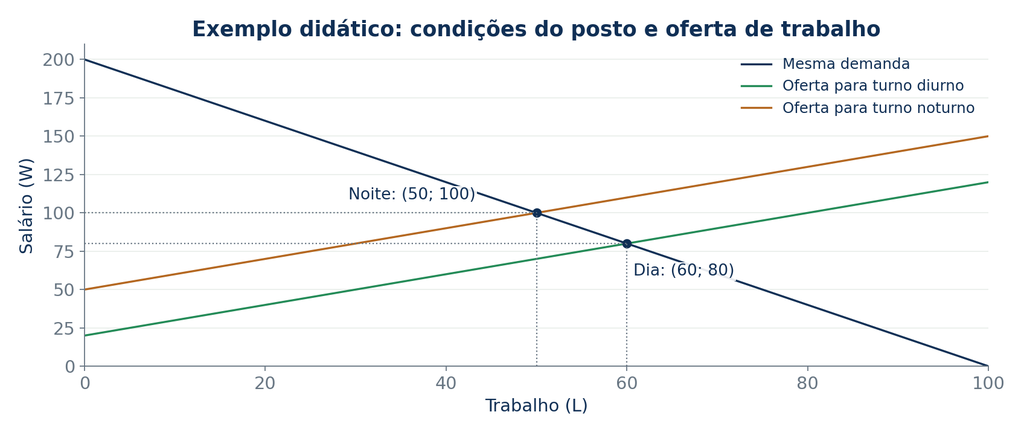

Duas ofertas de trabalho com a mesma demanda: turno diurno com salário 80 e noturno com salário 100

Fonte: elaboração didática. Dados hipotéticos, salvo indicação expressa.

**Simulação didática:** com a mesma demanda, menor disposição a trabalhar à noite eleva o salário de equilíbrio. A diferença de 20 unidades não é uma estimativa empírica.

← Menu

## 06 - Capital humano e rendimentos

Educação, treinamento e experiência podem ampliar capacidades produtivas. A formação exige investimento de tempo e recursos e pode elevar rendimentos futuros.

O retorno depende da aprendizagem e da demanda por habilidades. Uma competência pouco utilizada pode não gerar a remuneração esperada.

A formação também produz benefícios não salariais e externalidades. Seu valor social não pode ser reduzido apenas ao salário que alguém recebe.

Na análise empírica, escolaridade maior costuma estar associada a renda maior. Para medir um **efeito causal**, é preciso separar escolaridade de outras características e oportunidades.

← Menu

## 07 - O custo de estudar

Uma pessoa considera deixar o trabalho por um ano para estudar. Seu custo inclui mensalidades, materiais, mudança e renda que deixa de receber.

**Exemplo didático:** despesas adicionais de R$ 12 mil e renda anual abandonada de R$ 24 mil produzem custo de oportunidade de R$ 36 mil, antes de outros ajustes.

O benefício depende de salários futuros, chance de emprego, duração da carreira e preferências pessoais.

Restrições de crédito podem impedir um investimento com retorno esperado alto. Bolsas e provisão pública podem modificar as possibilidades de escolha.

← Menu

## 08 - Demanda por habilidades

O capítulo discute a valorização de habilidades a partir de mudanças no comércio e na tecnologia.

Tecnologias podem complementar tarefas qualificadas e substituir outras. A integração comercial pode ampliar a demanda por algumas atividades e expor outras à concorrência.

A oferta de pessoas com determinadas competências também importa. Se demanda cresce mais rapidamente que oferta, o diferencial de remuneração pode aumentar.

O resultado não é uma propriedade imutável de diplomas. Depende da estrutura produtiva, da difusão tecnológica e da formação de trabalhadores.

← Menu

## 09 - Habilidade, esforço e circunstâncias

Diferenças de desempenho podem refletir habilidades desenvolvidas, esforço, experiência e condições de trabalho. Também podem resultar de acaso, redes de contato e oportunidades.

Muitas dessas características são difíceis de observar. A mesma pessoa pode apresentar resultados diferentes com equipamentos, gestão ou acesso a informação distintos.

Assim, renda elevada não é uma medida pura de esforço individual, e renda baixa não demonstra falta de empenho.

O capítulo incorpora habilidade, esforço e sorte para mostrar por que uma explicação baseada apenas em escolaridade e anos de experiência é incompleta.

← Menu

## 10 - Aparência e remuneração

O livro apresenta pesquisas que relacionam aparência e rendimentos. Elas motivam perguntas sobre seleção, preferência dos clientes e tratamento diferenciado.

Uma associação estatística pode refletir vários mecanismos, inclusive discriminação. Não autoriza concluir que aparência determine capacidade geral ou valor de uma pessoa.

O desenho da pesquisa precisa distinguir ocupações, características observáveis, avaliações subjetivas e seleção para o emprego.

Esse exemplo prepara o problema central da aula: **como separar diferenças relevantes para uma tarefa de barreiras e preferências discriminatórias?**

← Menu

## 11 - Educação como sinal

Na teoria da sinalização, o diploma informa ao empregador uma característica que ele não observa diretamente. Parte do retorno à educação pode decorrer dessa informação.

Para funcionar como sinal separador, obter o diploma precisa ter custos ou dificuldades diferentes entre tipos de trabalhadores. Caso todos possam reproduzir o sinal ao mesmo custo, ele perde poder de distinção.

Na versão pura, a educação revela produtividade previamente existente sem aumentá-la. Na prática, **formação e sinalização podem coexistir**.

Retomamos o capítulo 22: sinais ajudam a lidar com informação assimétrica, mas também podem excluir quem enfrenta custos maiores de acesso.

← Menu

## 12 - Capital humano e sinalização

| Pergunta | Capital humano | Sinalização pura |
| --- | --- | --- |
| O que a educação faz? | Desenvolve capacidade produtiva | Revela uma característica já existente |
| Por que o salário aumenta? | Maior produtividade | Informação usada na contratação |
| O que a associação diploma-salário prova? | Sozinha, não prova causalidade | Sozinha, não identifica sinalização |

Políticas podem ter consequências diferentes em cada mecanismo. A expansão educacional exige avaliar aprendizagem, oportunidades e credenciais, em vez de pressupor que todo retorno salarial tenha uma única origem.

← Menu

## 13 - Como investigar o retorno da educação

Pessoas que estudam mais também podem diferir em renda familiar, escola anterior, saúde, redes e oportunidades. Uma comparação simples de salários mistura esses fatores.

Pesquisas usam controles e desenhos que procuram encontrar variação de escolaridade independente dessas diferenças. Mudanças institucionais podem fornecer comparações úteis, desde que suas hipóteses sejam verificadas.

Uma estimativa causal depende da qualidade do desenho. Acrescentar muitas variáveis a uma regressão não resolve automaticamente toda seleção.

Também é preciso distinguir retorno privado, retorno social e efeitos de qualidade do ensino.

← Menu

## 14 - Jogo rápido: dois mecanismos

Uma empresa valoriza um certificado. Em um caso, o curso ensina uma técnica que aumenta a produção. Em outro, o certificado apenas seleciona quem já dominava a técnica.

1. Qual caso representa formação de capital humano?
2. Qual representa sinalização?
3. A diferença de salário observada entre certificados e não certificados permite escolher entre as duas explicações?

**Conferir respostas**

1. O primeiro. 2. O segundo. 3. Não. Precisamos investigar o que mudou na capacidade produtiva e quais diferenças já existiam entre os grupos. Os dois mecanismos podem operar juntos.

← Menu

## 15 - O fenômeno das superestrelas

Algumas atividades permitem que uma pessoa atenda um mercado enorme com baixo custo adicional de reprodução. Uma gravação pode alcançar milhões de consumidores.

Quando muitos preferem um mesmo fornecedor e é possível atender a essa demanda em grande escala, pequenas diferenças percebidas podem gerar diferenças muito grandes de renda.

O capítulo contrasta artistas e atletas de destaque com profissões que exigem atendimento individual e têm maior limite de escala.

Tecnologia, alcance do mercado e preferências ajudam a explicar o resultado. A remuneração excepcional não significa produtividade física proporcionalmente maior em qualquer atividade.

← Menu

## 16 - Remuneração acima do equilíbrio

O salário pode permanecer acima do nível que igualaria oferta e demanda no modelo competitivo simples.

O capítulo aponta três mecanismos: pisos legais, negociação sindical e salários de eficiência.

Eles não são equivalentes. Uma norma estabelece um limite. Um sindicato negocia coletivamente. Uma empresa pode escolher pagar mais por considerar que isso melhora seu próprio resultado.

Os efeitos sobre emprego dependem do poder de mercado, da reação da produtividade e das condições institucionais. A aula 24 aprofundará os mecanismos relacionados ao desemprego.

← Menu

## 17 - Salários de eficiência

Uma remuneração maior pode reduzir rotatividade, atrair melhores candidaturas, melhorar saúde ou tornar a perda do emprego mais custosa para quem reduz esforço.

Se esses efeitos elevam produtividade ou reduzem custos o suficiente, a empresa pode preferir um salário maior mesmo com candidatos disponíveis por menos.

**Exemplo didático:** economizar em treinamento e substituição de equipes pode compensar parte do pagamento adicional.

Essa explicação não afirma que qualquer aumento salarial se pague sozinho. O efeito depende do contexto e do mecanismo identificado.

← Menu

## 18 - O que significa discriminação?

Discriminação no mercado de trabalho ocorre quando pessoas comparáveis recebem tratamento diferente por características como raça, gênero ou origem, sem justificativa pertinente ao desempenho da atividade.

Pode aparecer na contratação, remuneração, promoção, distribuição de tarefas, acesso a treinamento ou desligamento.

Uma diferença salarial média é um sinal a investigar. Ela não identifica automaticamente todo o efeito discriminatório, porque grupos também diferem nas oportunidades e posições ocupadas.

O fato de uma diferença refletir escolaridade ou experiência não exclui que o acesso anterior a essas condições tenha sofrido discriminação.

← Menu

## 19 - Comparação bruta e comparação ajustada

Se um grupo recebe R$ 5.000 e outro R$ 4.000, a diferença bruta é 20% tomando o primeiro como referência.

Parte pode estar associada a horas, ocupação, experiência e escolaridade. Uma comparação ajustada procura controlar essas características.

O resultado ainda depende das variáveis disponíveis e das hipóteses do modelo. Características omitidas podem influenciar o resíduo. Por outro lado, controlar ocupação pode ocultar barreiras discriminatórias à entrada em certas carreiras.

**Nem toda diferença bruta é discriminação salarial direta. Nem todo resíduo mede perfeitamente a discriminação total.**

← Menu

## 20 - Um exemplo de composição

Dois grupos recebem o mesmo salário por hora, mas um trabalha, em média, 40 horas e outro 30 horas remuneradas por semana. A renda semanal será diferente.

Isso explica a diferença contábil imediata, mas abre outra pergunta: por que as jornadas diferem?

Responsabilidades de cuidado, falta de creches, restrições dos empregadores e preferências podem produzir composições diferentes. Explicar a jornada não equivale a demonstrar ausência de barreiras.

A análise deve distinguir **o mecanismo próximo da diferença** e **as condições que produziram esse mecanismo**.

← Menu

## 21 - Experimentos com currículos

O capítulo apresenta uma pesquisa que enviou currículos comparáveis com nomes que sinalizavam diferentes associações raciais para vagas nos Estados Unidos.

Ao variar o sinal e manter características do currículo semelhantes, os pesquisadores puderam examinar diferenças nas respostas de empregadores.

Esse desenho produz evidência mais específica sobre o estágio inicial da contratação do que comparar apenas salários médios. Ainda assim, o resultado depende do contexto e do significado atribuído aos nomes.

Ele não observa sozinho toda a trajetória de contratação, promoção e remuneração ao longo da carreira.

← Menu

## 22 - Discriminação por empregadores

Um empregador pode aceitar custos maiores para evitar contratar um grupo, mesmo quando há trabalhadores igualmente produtivos disponíveis por remuneração menor.

No argumento competitivo apresentado no livro, empresas sem essa preferência poderiam contratar esses trabalhadores, produzir a menor custo e ampliar sua participação.

Essa pressão pode limitar a discriminação, mas depende de concorrência, entrada, informação e mobilidade. Barreiras à mudança de emprego e redes de contratação podem preservar diferenças.

**Um mecanismo de redução não constitui uma garantia de eliminação.** O mercado pode conviver com discriminação persistente.

← Menu

## 23 - Preferências dos consumidores

Se consumidores discriminam trabalhadores, a decisão da empresa pode refletir a perda de receitas esperada ao contratar determinadas pessoas.

Nesse caso, uma empresa que busca lucro pode reproduzir o tratamento desigual, mesmo sem preferência pessoal do empregador contra o grupo.

O livro discute exemplos em atendimento e esportes para mostrar a diferença entre discriminação do empregador e do cliente.

Isso enfraquece a ideia de que a competição necessariamente resolverá o problema. O incentivo econômico privado pode estar alinhado à manutenção da discriminação.

← Menu

## 24 - Governo, regras e segregação

O Estado pode combater discriminação, mas também pode instituir regras que a reforcem. O capítulo usa a segregação histórica em bondes como exemplo de conflito entre regras discriminatórias, custos e interesses empresariais.

Uma prática imposta legalmente não desaparece apenas porque algumas empresas prefeririam operar de outra forma.

A história mostra que direitos, fiscalização e mudanças institucionais participam da explicação econômica.

Analisar os incentivos das empresas ajuda a entender o mecanismo, mas não substitui o reconhecimento dos danos e das restrições de direitos sofridos pelas pessoas.

← Menu

## 25 - Políticas e avaliação

Regras de igualdade, transparência salarial, fiscalização, processos de seleção estruturados e ampliação de acesso a formação podem enfrentar mecanismos diferentes de discriminação.

O desenho precisa identificar onde ocorre a barreira. Uma diferença na seleção exige instrumentos distintos de uma diferença nas promoções internas.

Avalie efeitos sobre acesso, remuneração, permanência e qualidade do emprego. Observar apenas quantas pessoas foram contratadas pode omitir desigualdade nas tarefas ou na progressão.

As políticas devem ser avaliadas por resultados e pelo respeito aos direitos, evitando transformar médias de grupos em estereótipos sobre indivíduos.

← Menu

## 26 - Jogo rápido: o que a evidência permite?

1. Dois grupos têm salário médio diferente. Isso mede exatamente a discriminação?
2. Currículos equivalentes recebem respostas diferentes quando muda apenas um sinal de identidade. Que evidência aparece?
3. Uma diferença ajustada é pequena. Isso prova igualdade de oportunidades em toda a trajetória?

**Conferir respostas**

1. Não. A composição também pode influenciar a média. 2. Evidência de tratamento desigual no estágio estudado, conforme as hipóteses do experimento. 3. Não. Barreiras anteriores podem ter influenciado escolaridade, ocupação e experiência, inclusive variáveis usadas no ajuste.

← Menu

## 27 - Conclusão: explicar sem naturalizar

Os rendimentos refletem características produtivas, condições dos postos, informação, dimensão dos mercados e instituições. Discriminação pode alterar tanto os pagamentos quanto o acesso às oportunidades que antecedem o emprego.

**Uma boa análise identifica mecanismos e limites da evidência.** Não reduz salário a mérito pessoal nem atribui toda diferença a uma única causa.

O modelo de produtividade marginal oferece uma referência. Para compreender trajetórias reais, precisamos incorporar informação, poder de negociação, barreiras e direitos.

Na próxima aula, veremos por que pessoas dispostas a trabalhar podem permanecer sem emprego.

← Menu

## Exercícios de concursos públicos

Oito exercícios selecionados. Nos itens de julgamento, use **C (certo/verdadeiro)** ou **E (errado/falso)**. Leia os enunciados antes de abrir as respostas. As fontes e as adaptações estão identificadas em cada questão.

### Questão 01

FGV, ALE/PR, Analista Legislativo, Economista, 2024, tipo 1 · questão 36

Deixar o trabalho para cursar pós-graduação implica qual custo pelo salário renunciado?

1. Monetário
2. Contábil
3. Oportunidade
4. Irrecuperável
5. Aluguel

Redação sintetizada para uso didático; dados e resposta preservados.

[Prova original](https://conhecimento.fgv.br/sites/default/files/concursos/analista-legislativo-economistae2cns04-tipo-1.pdf) · [Gabarito oficial](https://conhecimento.fgv.br/sites/default/files/concursos/ale-pr-gabarito-definitivo-cargos-do-edital-2.pdf)

Resposta comentada

### Questão 02

CESPE, Câmara dos Deputados, Analista Legislativo / Assistente Técnico, FC de Consultor Legislativo, Área V, 2002 · questão 68, 5º item

Uma das possíveis hipóteses para explicar o perfil dos salários entre categorias é a da existência de diferenciais compensatórios, o que é tratado exaustivamente na teoria hedônica dos salários.

**( ) C ( ) E**

Item original C/E, com normalização de espaçamento. A prova autoriza reprodução com indicação da fonte.

[Prova original](https://cdn.cebraspe.org.br/concursos/_antigos/2003/camaradosdeputados/ARQUIVOS/area_05.pdf) · [Gabarito oficial](https://cdn.cebraspe.org.br/concursos/_antigos/2003/CAMARADOSDEPUTADOS/Arquivos/Gab_Def_CD.pdf)

Resposta comentada

### Questão 03

CESPE, Câmara dos Deputados, Analista Legislativo / Assistente Técnico, FC de Consultor Legislativo, Área V, 2002 · questão 71, 1º item

Considere que, em média, no Brasil, os rendimentos do trabalho dos homens são superiores aos rendimentos do trabalho das mulheres. A partir da constatação dessa diferença de rendimentos por sexo, um economista neoclássico conclui que existe discriminação contra a mulher no mercado de trabalho.

**( ) C ( ) E**

Item original C/E, com normalização de espaçamento. A prova autoriza reprodução com indicação da fonte.

[Prova original](https://cdn.cebraspe.org.br/concursos/_antigos/2003/camaradosdeputados/ARQUIVOS/area_05.pdf) · [Gabarito oficial](https://cdn.cebraspe.org.br/concursos/_antigos/2003/CAMARADOSDEPUTADOS/Arquivos/Gab_Def_CD.pdf)

Resposta comentada

### Questão 04

CESPE, Câmara dos Deputados, Analista Legislativo / Assistente Técnico, FC de Consultor Legislativo, Área V, 2002 · questão 71, 2º item

Considere que, em média, os salários na região Nordeste são inferiores aos rendimentos do trabalho na região Sudeste. Exclusivamente a partir dessa constatação, um economista neoclássico não concluiria que existe segmentação no mercado de trabalho entre essas duas regiões.

**( ) C ( ) E**

Item original C/E, com normalização de espaçamento. A prova autoriza reprodução com indicação da fonte.

[Prova original](https://cdn.cebraspe.org.br/concursos/_antigos/2003/camaradosdeputados/ARQUIVOS/area_05.pdf) · [Gabarito oficial](https://cdn.cebraspe.org.br/concursos/_antigos/2003/CAMARADOSDEPUTADOS/Arquivos/Gab_Def_CD.pdf)

Resposta comentada

### Questão 05

CESPE, Câmara dos Deputados, Analista Legislativo / Assistente Técnico, FC de Consultor Legislativo, Área V, 2002 · questão 71, 3º item

A teoria do capital humano é um arcabouço analítico que tenta modernizar a teoria marxista do capital a fim de explicar a distribuição de renda entre capitalistas e assalariados nas sociedades pós-industriais.

**( ) C ( ) E**

Item original C/E, com normalização de espaçamento. A prova autoriza reprodução com indicação da fonte.

[Prova original](https://cdn.cebraspe.org.br/concursos/_antigos/2003/camaradosdeputados/ARQUIVOS/area_05.pdf) · [Gabarito oficial](https://cdn.cebraspe.org.br/concursos/_antigos/2003/CAMARADOSDEPUTADOS/Arquivos/Gab_Def_CD.pdf)

Resposta comentada

### Questão 06

CESPE, Câmara dos Deputados, Analista Legislativo / Assistente Técnico, FC de Consultor Legislativo, Área V, 2002 · questão 71, 5º item

Para os partidários do arcabouço teórico neoclássico, a segmentação do mercado por gênero, raça e região tem custos em termos sociais, mas, em termos econômicos, eleva a eficiência alocativa do mercado de trabalho.

**( ) C ( ) E**

Item original C/E, com normalização de espaçamento. A prova autoriza reprodução com indicação da fonte.

[Prova original](https://cdn.cebraspe.org.br/concursos/_antigos/2003/camaradosdeputados/ARQUIVOS/area_05.pdf) · [Gabarito oficial](https://cdn.cebraspe.org.br/concursos/_antigos/2003/CAMARADOSDEPUTADOS/Arquivos/Gab_Def_CD.pdf)

Resposta comentada

### Questão 07

CESPE, Senado Federal, Consultor Legislativo, Área 14, 2002 · questão 73, 4º item

Há evidências empíricas demonstrando que o emprego feminino tende a ser concentrado em determinados setores da economia e agrupado em um conjunto limitado de profissões, sendo essa segmentação um dos pilares das desigualdades entre homens e mulheres no mercado de trabalho.

**( ) C ( ) E**

Item original C/E, com normalização de espaçamento. A prova autoriza reprodução com indicação da fonte.

[Prova original](https://cdn.cebraspe.org.br/concursos/_antigos/2002/senado/Arquivos/area_14_LEGISL_1Et.pdf) · [Gabarito oficial](https://cdn.cebraspe.org.br/concursos/_antigos/2002/senado/Arquivos/Gab_Def-SENADO.pdf)

Resposta comentada

### Questão 08

CESPE, Senado Federal, Consultor Legislativo, Área 14, 2002 · questão 73, 5º item

Estudos demonstram que o hiato de rendimentos entre homens e mulheres não é afetado pela variável raça, ou seja, o diferencial de remuneração entre mulheres brancas e negras é, do ponto de vista estatístico, insignificante.

**( ) C ( ) E**

Item original C/E, com normalização de espaçamento. A prova autoriza reprodução com indicação da fonte.

[Prova original](https://cdn.cebraspe.org.br/concursos/_antigos/2002/senado/Arquivos/area_14_LEGISL_1Et.pdf) · [Gabarito oficial](https://cdn.cebraspe.org.br/concursos/_antigos/2002/senado/Arquivos/Gab_Def-SENADO.pdf)

Resposta comentada

**Gabarito resumido e resoluções comentadas**

| Questão | 01 | 02 | 03 | 04 | 05 | 06 | 07 | 08 |
| --- | --- | --- | --- | --- | --- | --- | --- | --- |
| Resposta | C | C | E | C | E | E | C | E |

**Questão 01: C**

A remuneração renunciada é custo de oportunidade. A decisão de investir em capital humano deve comparar custos atuais e benefícios futuros, sem confundir retorno esperado com garantia individual de ganho.

Voltar ao enunciado

**Questão 02: C**

Condições desagradáveis ou arriscadas podem exigir remuneração maior para atrair pessoas. Para identificar um diferencial compensatório, é preciso comparar trabalhadores e postos de maneira adequada; diferenças salariais não se explicam todas por esse mecanismo.

Voltar ao enunciado

**Questão 03: E**

A diferença média bruta não identifica isoladamente discriminação contra pessoas igualmente produtivas. É preciso examinar características, acesso a oportunidades e mecanismos. O erro está em tratar uma diferença observada como prova suficiente, não em negar que discriminação possa existir.

Voltar ao enunciado

**Questão 04: C**

Uma diferença regional de remuneração, sozinha, não separa produtividade, custo de vida, composição ocupacional e barreiras à mobilidade. A conclusão exige evidência adicional sobre os mecanismos e a comparação entre trabalhadores e postos.

Voltar ao enunciado

**Questão 05: E**

A teoria do capital humano analisa investimentos em conhecimentos, habilidades e saúde como determinantes da produtividade e dos rendimentos. A origem e a definição apresentadas no item não correspondem a essa abordagem.

Voltar ao enunciado

**Questão 06: E**

Restringir oportunidades por gênero, raça ou origem pode impedir a alocação de trabalhadores às atividades em que seriam mais produtivos. Custos sociais e perdas econômicas podem coexistir; a segmentação não garante eficiência maior.

Voltar ao enunciado

**Questão 07: C**

Concentração em ocupações específicas pode refletir barreiras de acesso, normas sociais, educação, cuidado e discriminação. A decomposição de rendimentos ajuda a estudar o fenômeno, mas exige cautela causal.

Voltar ao enunciado

**Questão 08: E**

O enunciado afirma irrelevância da raça sem sustentação. A análise deve considerar sobreposição de desigualdades e composição dos grupos. O gabarito rejeita a generalização; não fornece uma estimativa atual de tamanho do diferencial.

Voltar ao enunciado

← Menu